# DS 621 Fall2020: Homework 4 (Group3)

Auto Insurance Regression

Zach Alexander, Sam Bellows, Donny Lofland, Joshua Registe, Neil Shah, Aaron Zalki

Source code: https://github.com/djlofland/DS621_F2020_Group3/tree/master/Homework_4

## 0. Introduction

Group 3 created a multiple linear regression and binary logistic model to estimate the probability of a driver having an auto accident, and the monetary damage, for the customer Khansari Auto Insurance. As autoinsurance and insurance in general stems off the pooling of individuals to mitigate risk, it’s important to be able to predict accident rates to ensure funds are available for disbursement.

## 1. Data Exploration

*Describe the size and the variables in the insurance training data set. Consider that too much detail will cause a manager to lose interest while too little detail will make the manager consider that you aren’t doing your job. Some suggestions are given below. Please do NOT treat this as a checklist of things to do to complete the assignment.*

*You should have your own thoughts on what to tell the boss. These are just ideas.*

Given that the Index column had no impact on the target variable, it was dropped as part of the initial cleaning function. Additionally, the fields “INCOME”, “HOME_VAL”, “OLDCLAIM”, and, “BLUEBOOK”, were imported as characters with “$” leaders and were converted to numeric as part of the initial cleaning function. both the training and evaluation datasets will pass through this treatment.

Now, with initial cleaning complete, we can take a quick look at the dimensions of both the training and evaluation datasets:

**Dimensions of training dataset**

```
## [1] 8161   25
```

**Dimensions of evaluation dataset**

```
## [1] 2141   25
```

It looks like we have 8,161 cases and 25 variables in the training dataset and 2,141 cases and 25 variables in the evaluation dataset.

We can also provide a summary of each variable and it’s theoretical effect it’ll have on our models:

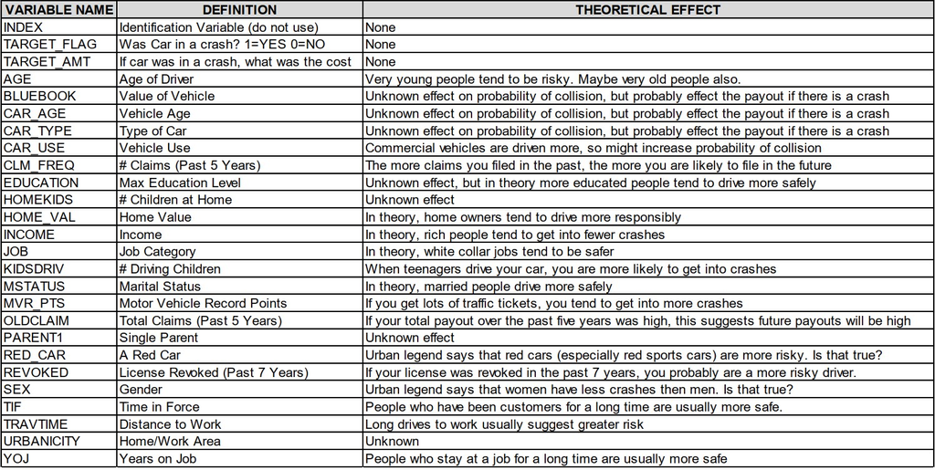

Variables of Interest

### Summary Stats

Next, we compiled summary statistics on our data set to better understand the data before modeling.

```
##  TARGET_FLAG   TARGET_AMT        KIDSDRIV           AGE           HOMEKIDS
##  0:6008      Min.   :     0   Min.   :0.0000   Min.   :16.00   Min.   :0.0000
##  1:2153      1st Qu.:     0   1st Qu.:0.0000   1st Qu.:39.00   1st Qu.:0.0000
##              Median :     0   Median :0.0000   Median :45.00   Median :0.0000
##              Mean   :  1504   Mean   :0.1711   Mean   :44.79   Mean   :0.7212
##              3rd Qu.:  1036   3rd Qu.:0.0000   3rd Qu.:51.00   3rd Qu.:1.0000
##              Max.   :107586   Max.   :4.0000   Max.   :81.00   Max.   :5.0000
##                                                NA's   :6
##       YOJ           INCOME         PARENT1             HOME_VAL
##  Min.   : 0.0   Min.   :     0   Length:8161        Min.   :     0
##  1st Qu.: 9.0   1st Qu.: 28097   Class :character   1st Qu.:     0
##  Median :11.0   Median : 54028   Mode  :character   Median :161160
##  Mean   :10.5   Mean   : 61898                      Mean   :154867
##  3rd Qu.:13.0   3rd Qu.: 85986                      3rd Qu.:238724
##  Max.   :23.0   Max.   :367030                      Max.   :885282
##  NA's   :454    NA's   :445                         NA's   :464
##    MSTATUS              SEX             EDUCATION             JOB
##  Length:8161        Length:8161        Length:8161        Length:8161
##  Class :character   Class :character   Class :character   Class :character
##  Mode  :character   Mode  :character   Mode  :character   Mode  :character
##
##
##
##
##     TRAVTIME        CAR_USE             BLUEBOOK          TIF
##  Min.   :  5.00   Length:8161        Min.   : 1500   Min.   : 1.000
##  1st Qu.: 22.00   Class :character   1st Qu.: 9280   1st Qu.: 1.000
##  Median : 33.00   Mode  :character   Median :14440   Median : 4.000
##  Mean   : 33.49                      Mean   :15710   Mean   : 5.351
##  3rd Qu.: 44.00                      3rd Qu.:20850   3rd Qu.: 7.000
##  Max.   :142.00                      Max.   :69740   Max.   :25.000
##
##    CAR_TYPE           RED_CAR             OLDCLAIM        CLM_FREQ
##  Length:8161        Length:8161        Min.   :    0   Min.   :0.0000
##  Class :character   Class :character   1st Qu.:    0   1st Qu.:0.0000
##  Mode  :character   Mode  :character   Median :    0   Median :0.0000
##                                        Mean   : 4037   Mean   :0.7986
##                                        3rd Qu.: 4636   3rd Qu.:2.0000
##                                        Max.   :57037   Max.   :5.0000
##
##    REVOKED             MVR_PTS          CAR_AGE        URBANICITY
##  Length:8161        Min.   : 0.000   Min.   :-3.000   Length:8161
##  Class :character   1st Qu.: 0.000   1st Qu.: 1.000   Class :character
##  Mode  :character   Median : 1.000   Median : 8.000   Mode  :character
##                     Mean   : 1.696   Mean   : 8.328
##                     3rd Qu.: 3.000   3rd Qu.:12.000
##                     Max.   :13.000   Max.   :28.000
##                                      NA's   :510
```

### Check Class Bias

Next, we wanted to get an idea of the distribution profiles for each of the variables. We have two target values, 0 and 1. When building models, we ideally want an equal representation of both classes. As class imbalance deviates, our model performance will suffer both from effects of differential variance between the classes and bias towards picking the more represented class. For logistic regression, if we see a strong imbalance, we can 1) up-sample the smaller group, down-sample the larger group, or adjust our threshold for assigning the predicted value away from 0.5.

| Classification of Target Flag Var1 | Classification of Target Flag Freq |
| --- | --- |
| 0 | 0.7361843 |
| 1 | 0.2638157 |

The classes are not perfectly balanced, with approximately 73.6% 0’s and 26.4% 1’s. With unbalanced class distributions, it is often necessary to artificially balance the classes to achieve good results. Up-sampling or Down-sampling may be required to achieve class balance with this dataset. We will evaluate model performance accordingly.

### Distributions

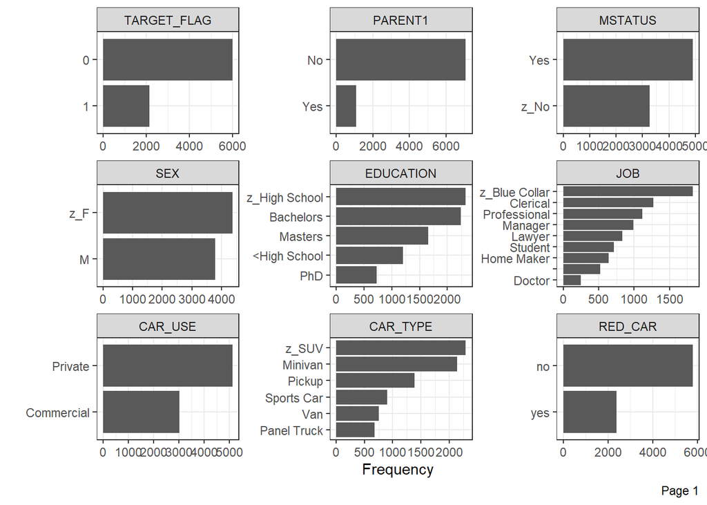

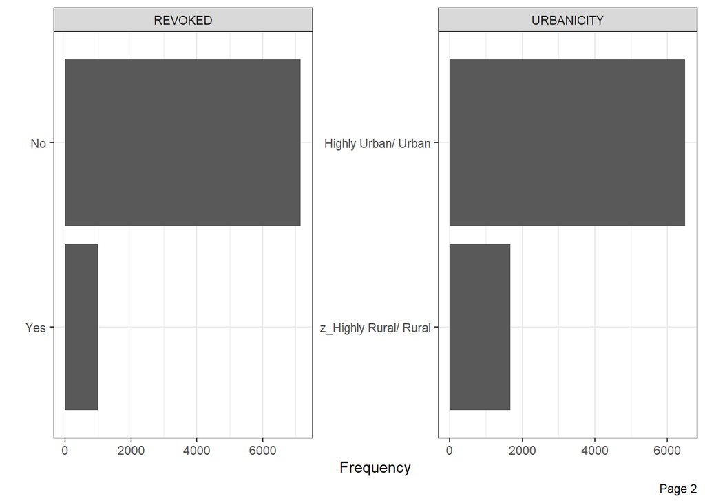

Next, we visualize the distribution profiles for each of the predictor variables. This will help us to make a plan on which variables to include, how they might be related to each other or the target, and finally identify outliers or transformations that might help improve model resolution.

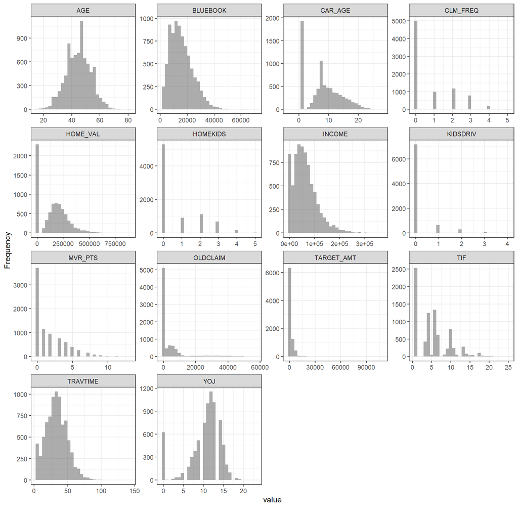

The distribution profiles show the prevalence of kurtosis, specifically right skew in variables `TRAVTIME`, `OLDCLAIM`, `MVR_PTS`, `TARGET_AMT`, `INCOME`, `BLUEBOOK`, and approximately normal distributions in `YOJ`, `CARAGE`, `HOME_VAL`, and `AGE`. When deviations are skewed from traditional normal distribution, this can be problematic for regression assumptions, and thus we might need to transform the data. Under logistic regression, we will need to dummy factor-based variables for the model to understand the data.

While we don’t tackle feature engineering in this analysis, if we were performing a more in-depth analysis, we could leverage the package, `mixtools` (see R Vignette). This package helps regress *mixed models* where data can be subdivided into subgroups.

Lastly, several features have both a distribution along with a high number of values at an extreme. However, based on the feature meanings and provided information, there is no reason to believe that any of these extreme values are mistakes, data errors, or otherwise inexplicable. As such, we will not remove the extreme values, as they represent valuable data and could be predictive of the target.

### Boxplots

In addition to creating histogram distributions, we also elected to use box-plots to get an idea of the spread of the response variable `TARGET_AMT` in relation to all of the non-numeric variables. Two sets of boxplots are shown below due to the wide distribution of the response variable. The first set of boxplots highlights the entire range and shows how the cost of car crashes peaks relative to the specific category.

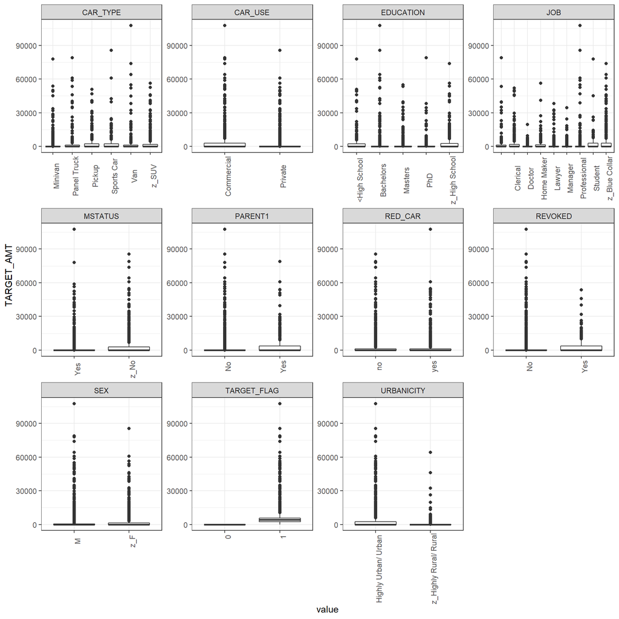

The second set of box plots simply shows these same distributions “zoomed in” by adjusting the axis to allow for a visual of the interquartile range of the response variable relative to each of the categorical predictors.

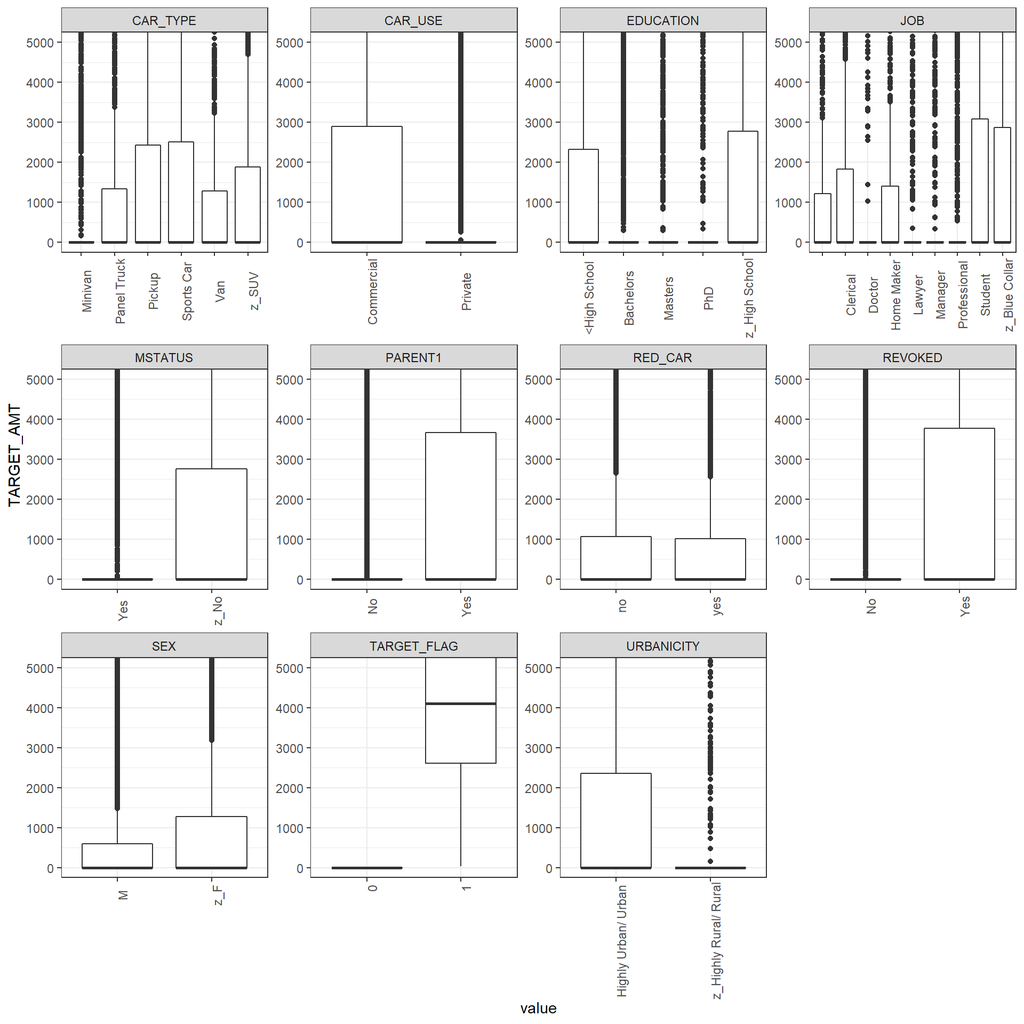

### Variable Plots

We wanted to plot scatter plots of each variable versus the target variable to get an idea of the relationship between them. There are some notable trends as observed in the scatterplots below such as our response variable `TARGET_AMT` is likely to be lower when individuals have more kids at home as indicated by the `HOMEKIDS` feature, and when they have more teenagers driving the car indicated by the feature `KIDSDRIV`.

Additionally a pairwise comparison plot between all features, both numeric and non-numeric is shown following the scatterplot where this initially implies that there aren’t a significant amount of correlated features and this can give some insight into the expected significance and performing dimensionality reduction on the datasets for the models.

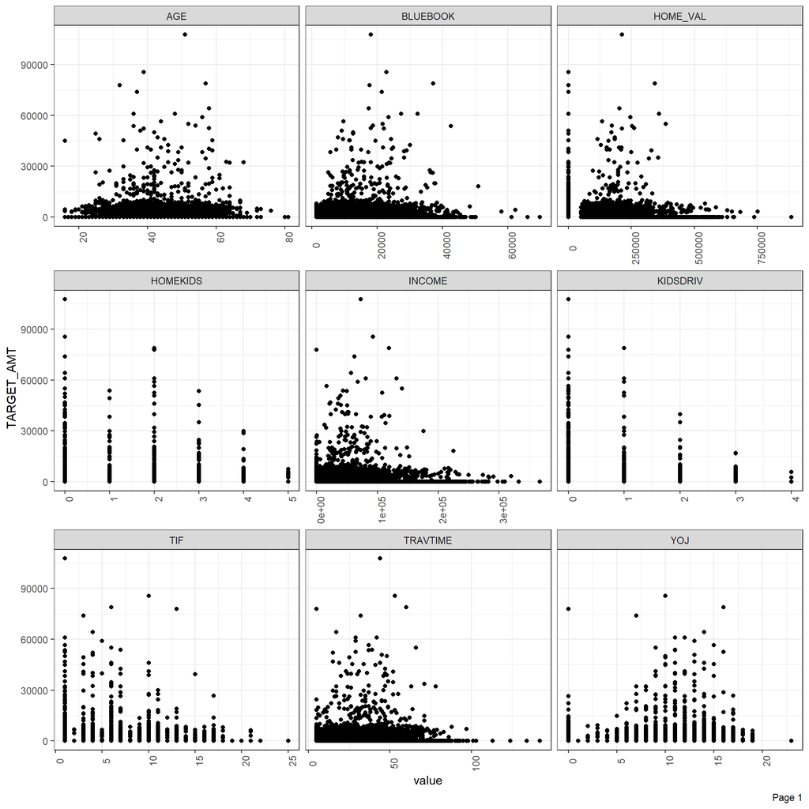

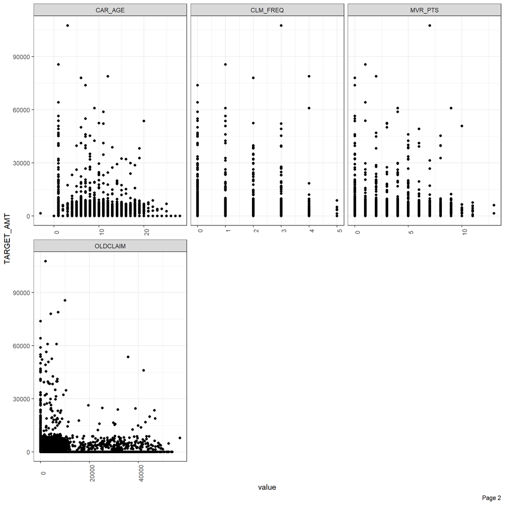

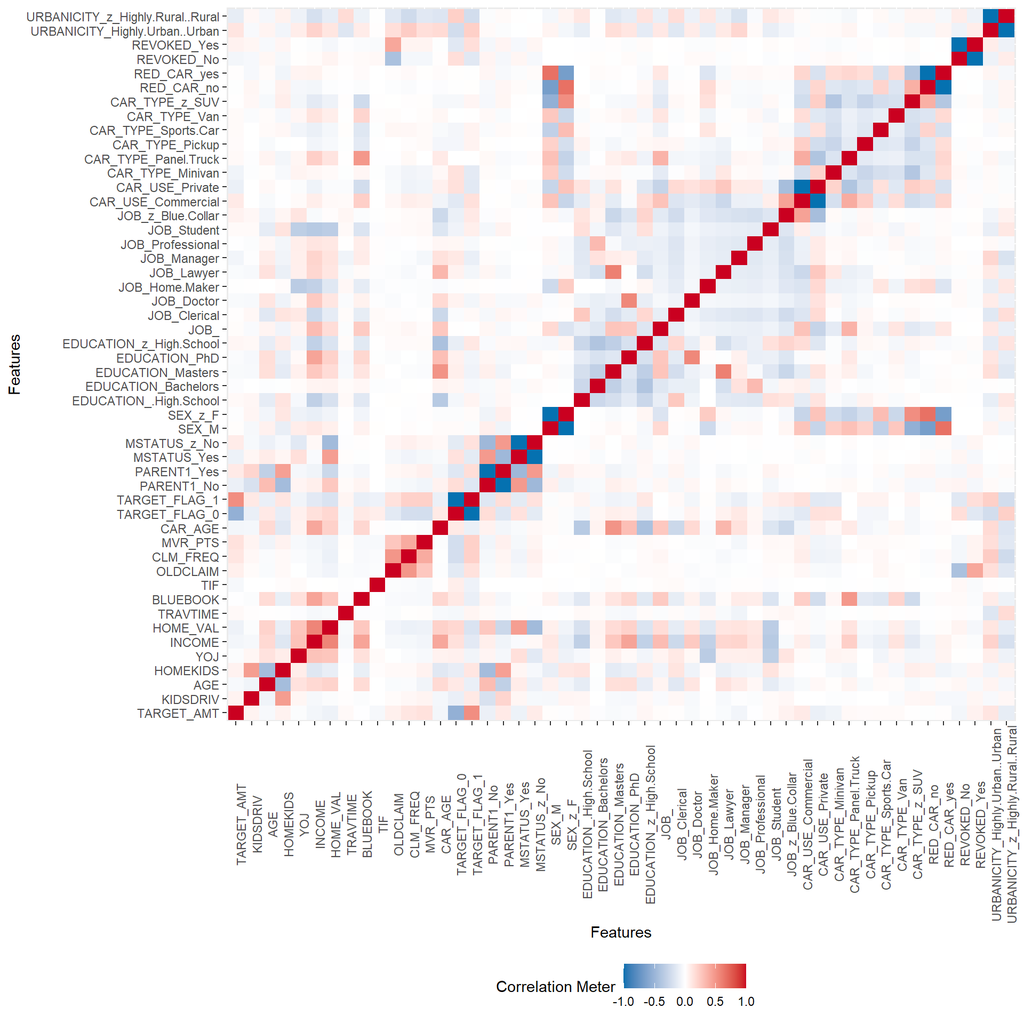

### Data Sparsity Check

Finally, we can observe the sparsity of information within our dataset by using the `DataExplorer` package to assess missing information.

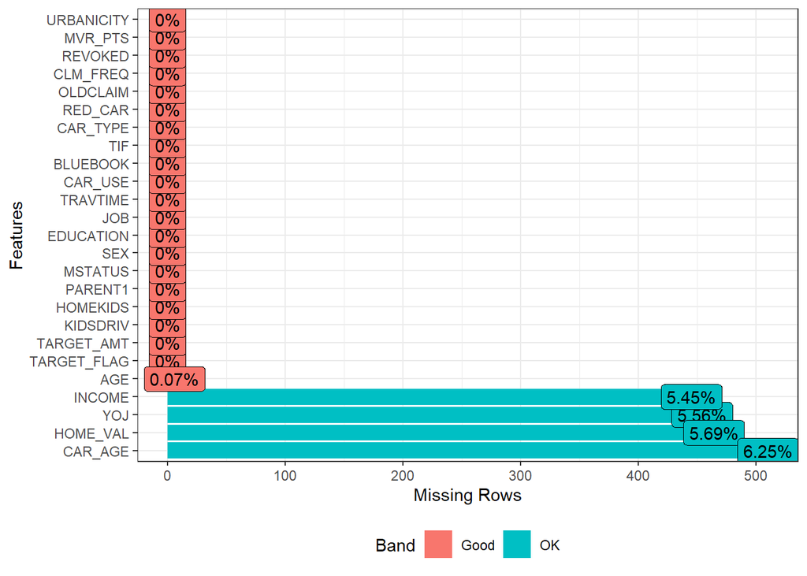

We can see that generally, our dataset is in good shape, however, some imputation may be needed for `INCOME`, `YOJ`, `HOME_VAL`, and `CAR_AGE`.

## 2. Data Preparation

To summarize our data preparation and exploration, we can distinguish our findings into a few categories below:

### Removed Fields

All the predictor variables have a low enough percentage of missing values that they can be imputed and still provide useful information to the model. As such, we chose to keep all the fields.

### Missing Values

Missing values will be imputed with the preprocess function in the caret package

```r
imputation <- preProcess(df, method = "knnImpute")
predict_imputer <- predict(imputation, df)
#compare to above chart
missing2 <- predict_imputer %>%
  miss_var_summary()
kable(missing2 %>%
  filter(pct_miss > 0)) %>%
  kable_styling(bootstrap_options = c("striped", "hover", "condensed"))
```

| variable | n_miss | pct_miss |
| --- | --- | --- |

```r
table_names <- data.frame(col = names(imputation$mean), mean = imputation$mean, sd = imputation$std)
for(i in table_names$col){
  predict_imputer[i] <- predict_imputer[i]*imputation$std[i] + imputation$mean[i]
}
```

### Outliers

No outliers were removed as all values seemed reasonable.

### Transform non-normal variables

Finally, as mentioned earlier in our data exploration, and our findings from our histogram plots, we can see that some of our variables are highly skewed. To address this, we decided to perform some transformations to make them more normally distributed. Here are some plots to demonstrate the changes in distributions before and after the transformations:

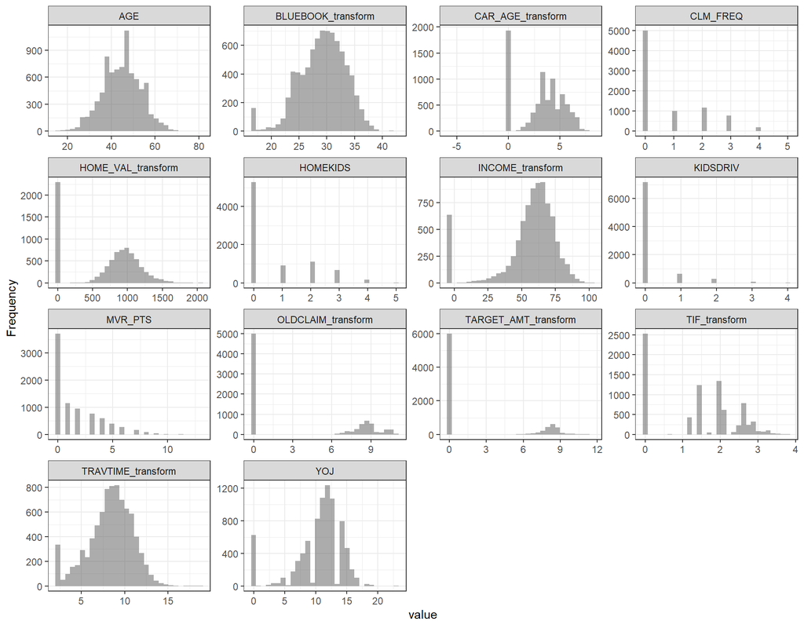

## 3. Build Models

*Using the training data, build at least two different multiple linear regression models and three different binary logistic models, using different variables (or the same variables with different transformations). You may select the variables manually, use an approach such as Forward or Stepwise, use a different approach, or use a combination of techniques. Describe the techniques you used. If you manually selected a variable for inclusion into the model or exclusion into the model, indicate why this was done.*

*Be sure to explain how you can make inferences from the model, as well as discuss other relevant model output. Discuss the coefficients in the models, do they make sense? Are you keeping the model even though it is counter-intuitive? Why? The boss needs to know.*

### Linear Regression

#### Linear Regression Model 1

The first model built was based on the entire dataset. The linear models will be attempting to predict the feature “TARGET_AMT” using the existing features within the dataset except for “TARGET_FLAG”. These features are to be considered unknown.

First, we decided to split our cleaned dataset into a training and testing set (75% training, 25% testing). This was necessary as the provided holdout evaluation dataset doesn’t provide target values so we cannot measure our model performance against that dataset. This split was used on all models

**First linear regression model, no transformations, all numeric predictors included**

```
##
## Call:
## stats::lm(formula = TARGET_AMT ~ AGE + BLUEBOOK + CAR_AGE + CLM_FREQ +
##     HOME_VAL + HOMEKIDS + INCOME + KIDSDRIV + MVR_PTS + OLDCLAIM +
##     TIF + TRAVTIME + YOJ + CAR_TYPE + CAR_USE + EDUCATION + JOB +
##     MSTATUS + PARENT1 + RED_CAR + REVOKED + SEX + URBANICITY,
##     data = data)
##
## Residuals:
##    Min     1Q Median     3Q    Max
##  -5586  -1697   -789    319 103372
##
## Coefficients:
##                                   Estimate Std. Error t value Pr(>|t|)
## (Intercept)                      1.196e+03  6.610e+02   1.809  0.07046 .
## AGE                              4.701e+00  8.397e+00   0.560  0.57562
## BLUEBOOK                         1.192e-02  1.037e-02   1.150  0.25027
## CAR_AGE                         -4.595e+01  1.519e+01  -3.025  0.00250 **
## CLM_FREQ                         1.216e+02  6.545e+01   1.858  0.06318 .
## HOME_VAL                        -1.122e-03  7.249e-04  -1.547  0.12190
## HOMEKIDS                         8.651e+01  7.783e+01   1.112  0.26639
## INCOME                          -3.342e-03  2.268e-03  -1.474  0.14064
## KIDSDRIV                         2.970e+02  1.350e+02   2.199  0.02791 *
## MVR_PTS                          1.796e+02  3.091e+01   5.809 6.59e-09 ***
## OLDCLAIM                        -1.154e-02  8.826e-03  -1.308  0.19105
## TIF                             -5.958e+01  1.454e+01  -4.097 4.24e-05 ***
## TRAVTIME                         1.116e+01  3.831e+00   2.912  0.00360 **
## YOJ                             -1.435e+01  1.792e+01  -0.801  0.42319
## CAR_TYPEPanel Truck              1.829e+02  3.302e+02   0.554  0.57967
## CAR_TYPEPickup                   2.429e+02  2.025e+02   1.200  0.23026
## CAR_TYPESports Car               1.053e+03  2.594e+02   4.059 4.98e-05 ***
## CAR_TYPEVan                      7.123e+02  2.518e+02   2.829  0.00468 **
## CAR_TYPEz_SUV                    6.835e+02  2.146e+02   3.185  0.00145 **
## CAR_USEPrivate                  -7.580e+02  1.942e+02  -3.904 9.56e-05 ***
## EDUCATIONBachelors               2.072e+00  2.426e+02   0.009  0.99319
## EDUCATIONMasters                 3.645e+02  3.570e+02   1.021  0.30724
## EDUCATIONPhD                     6.416e+02  4.219e+02   1.521  0.12842
## EDUCATIONz_High School           1.805e+01  2.045e+02   0.088  0.92966
## JOBClerical                      6.944e+02  4.050e+02   1.715  0.08645 .
## JOBDoctor                       -3.627e+02  4.833e+02  -0.751  0.45297
## JOBHome Maker                    4.854e+02  4.339e+02   1.119  0.26329
## JOBLawyer                        2.991e+02  3.513e+02   0.851  0.39454
## JOBManager                      -2.915e+02  3.422e+02  -0.852  0.39434
## JOBProfessional                  6.865e+02  3.658e+02   1.877  0.06058 .
## JOBStudent                       4.244e+02  4.461e+02   0.951  0.34144
## JOBz_Blue Collar                 8.108e+02  3.815e+02   2.125  0.03362 *
## MSTATUSz_No                      5.423e+02  1.747e+02   3.104  0.00191 **
## PARENT1Yes                       3.826e+02  2.400e+02   1.594  0.11100
## RED_CARyes                      -1.143e+02  1.786e+02  -0.640  0.52221
## REVOKEDYes                       4.836e+02  2.052e+02   2.357  0.01843 *
## SEXz_F                          -3.626e+02  2.194e+02  -1.653  0.09846 .
## URBANICITYz_Highly Rural/ Rural -1.656e+03  1.658e+02  -9.989  < 2e-16 ***
## ---
## Signif. codes:  0 '***' 0.001 '**' 0.01 '*' 0.05 '.' 0.1 ' ' 1
##
## Residual standard error: 4675 on 6083 degrees of freedom
## Multiple R-squared:  0.06739,    Adjusted R-squared:  0.06172
## F-statistic: 11.88 on 37 and 6083 DF,  p-value: < 2.2e-16
```

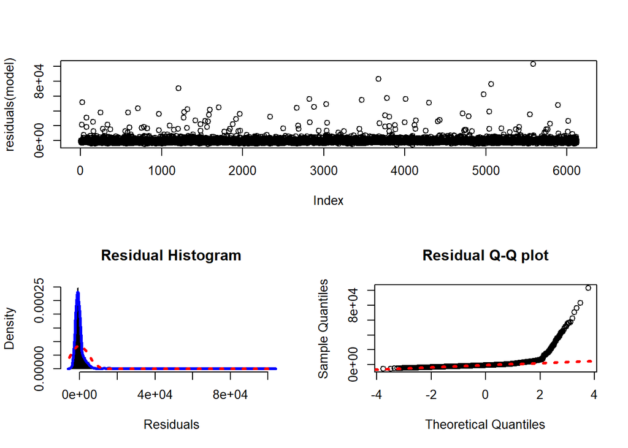

Results of the first model show that using all non-transformed data doesn’t fully satisfy the assumptions for a linear regression model. We can also see several predictors that show insignificant correlations but before we discount any features, we will use the transformed data to satisfy the conditions of linear regression. Our R2 was 0.06 and our error was 4675 which is indicative of a very poor model.

#### Linear Regression Model 2

The second model built was based on the entire dataset as well but various features were transformed as discussed in the Data Preparation section of this assignment. with our transformed variables via boxcox and linear transformations, linear regression was applied to the remaining data to assess predictability of our response variable.

```
##
## Call:
## stats::lm(formula = TARGET_AMT_transform ~ ., data = data)
##
## Residuals:
##     Min      1Q  Median      3Q     Max
## -7.8072 -2.3239 -0.9094  1.9629 10.4832
##
## Coefficients:
##                                   Estimate Std. Error t value Pr(>|t|)
## (Intercept)                      3.6525701  0.5896527   6.194 6.23e-10 ***
## AGE                              0.0022763  0.0058109   0.392 0.695268
## BLUEBOOK_transform              -0.0450465  0.0135550  -3.323 0.000895 ***
## CAR_AGE_transform               -0.0436398  0.0260314  -1.676 0.093706 .
## CAR_TYPEPanel Truck              0.2696825  0.2176776   1.239 0.215427
## CAR_TYPEPickup                   0.5349225  0.1397707   3.827 0.000131 ***
## CAR_TYPESports Car               1.0611065  0.1783942   5.948 2.86e-09 ***
## CAR_TYPEVan                      0.6540534  0.1734607   3.771 0.000164 ***
## CAR_TYPEz_SUV                    0.7966993  0.1452430   5.485 4.29e-08 ***
## CAR_USEPrivate                  -0.9603331  0.1341355  -7.159 9.06e-13 ***
## CLM_FREQ                         0.1265979  0.0706179   1.793 0.073068 .
## EDUCATIONBachelors              -0.2608015  0.1689184  -1.544 0.122653
## EDUCATIONMasters                -0.0405783  0.2415543  -0.168 0.866598
## EDUCATIONPhD                     0.0610753  0.2802850   0.218 0.827511
## EDUCATIONz_High School           0.1607296  0.1416156   1.135 0.256432
## HOME_VAL_transform              -0.0004504  0.0001237  -3.642 0.000272 ***
## HOMEKIDS                         0.0768615  0.0540685   1.422 0.155206
## INCOME_transform                -0.0149842  0.0040164  -3.731 0.000193 ***
## JOBClerical                      0.7530586  0.2775453   2.713 0.006681 **
## JOBDoctor                       -0.2722778  0.3337705  -0.816 0.414667
## JOBHome Maker                    0.2315929  0.3150573   0.735 0.462318
## JOBLawyer                        0.2394928  0.2422125   0.989 0.322814
## JOBManager                      -0.4610222  0.2360851  -1.953 0.050891 .
## JOBProfessional                  0.4794468  0.2521012   1.902 0.057244 .
## JOBStudent                       0.1418251  0.3272668   0.433 0.664767
## JOBz_Blue Collar                 0.7664547  0.2625805   2.919 0.003525 **
## KIDSDRIV                         0.5033165  0.0933104   5.394 7.15e-08 ***
## MSTATUSz_No                      0.5541900  0.1238162   4.476 7.75e-06 ***
## MVR_PTS                          0.1803303  0.0219374   8.220 2.46e-16 ***
## OLDCLAIM_transform               0.0152553  0.0198498   0.769 0.442198
## PARENT1Yes                       0.6159434  0.1655566   3.720 0.000201 ***
## RED_CARyes                      -0.0485750  0.1233161  -0.394 0.693664
## REVOKEDYes                       1.0131055  0.1286314   7.876 3.97e-15 ***
## SEXz_F                          -0.1151818  0.1485014  -0.776 0.437999
## TIF_transform                   -0.3134415  0.0387586  -8.087 7.32e-16 ***
## TRAVTIME_transform               0.0983533  0.0165498   5.943 2.96e-09 ***
## URBANICITYz_Highly Rural/ Rural -2.3793240  0.1150897 -20.674  < 2e-16 ***
## YOJ                             -0.0049852  0.0142641  -0.349 0.726729
## ---
## Signif. codes:  0 '***' 0.001 '**' 0.01 '*' 0.05 '.' 0.1 ' ' 1
##
## Residual standard error: 3.229 on 6083 degrees of freedom
## Multiple R-squared:  0.2267, Adjusted R-squared:  0.222
## F-statistic: 48.21 on 37 and 6083 DF,  p-value: < 2.2e-16
```

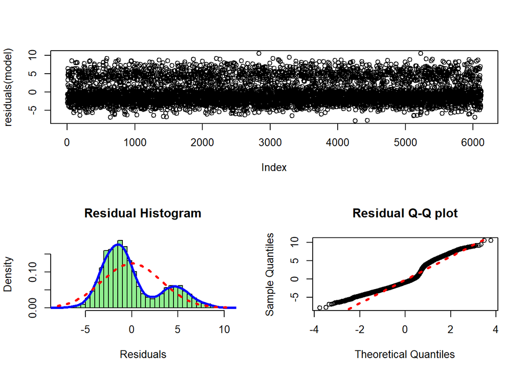

#### Linear Regression Model 3

This third model builds upon attempts to perform a linear regression by removing select features that are insignificant to the model created in model 2. In addition to feature selection, using the tidymodels framework, we removed any features that are highly correlated with each other as well as any zero-variance features. Only numeric features were considered in this model.

```
##
## Call:
## stats::lm(formula = TARGET_AMT_transform ~ ., data = data)
##
## Residuals:
##    Min     1Q Median     3Q    Max
## -6.875 -2.296 -1.261  2.823 10.407
##
## Coefficients:
##                      Estimate Std. Error t value Pr(>|t|)
## (Intercept)         3.593e+00  3.656e-01   9.826  < 2e-16 ***
## BLUEBOOK_transform -4.961e-02  1.099e-02  -4.514 6.49e-06 ***
## CAR_AGE_transform  -1.095e-01  2.121e-02  -5.162 2.52e-07 ***
## HOME_VAL_transform -9.218e-04  9.478e-05  -9.726  < 2e-16 ***
## HOMEKIDS            1.564e-01  4.534e-02   3.450 0.000564 ***
## KIDSDRIV            4.500e-01  9.747e-02   4.617 3.97e-06 ***
## MVR_PTS             2.262e-01  2.317e-02   9.764  < 2e-16 ***
## OLDCLAIM_transform  1.235e-01  1.151e-02  10.723  < 2e-16 ***
## TIF_transform      -3.069e-01  4.112e-02  -7.462 9.68e-14 ***
## TRAVTIME_transform  5.690e-02  1.733e-02   3.283 0.001034 **
## ---
## Signif. codes:  0 '***' 0.001 '**' 0.01 '*' 0.05 '.' 0.1 ' ' 1
##
## Residual standard error: 3.436 on 6111 degrees of freedom
## Multiple R-squared:  0.1208, Adjusted R-squared:  0.1195
## F-statistic: 93.28 on 9 and 6111 DF,  p-value: < 2.2e-16
```

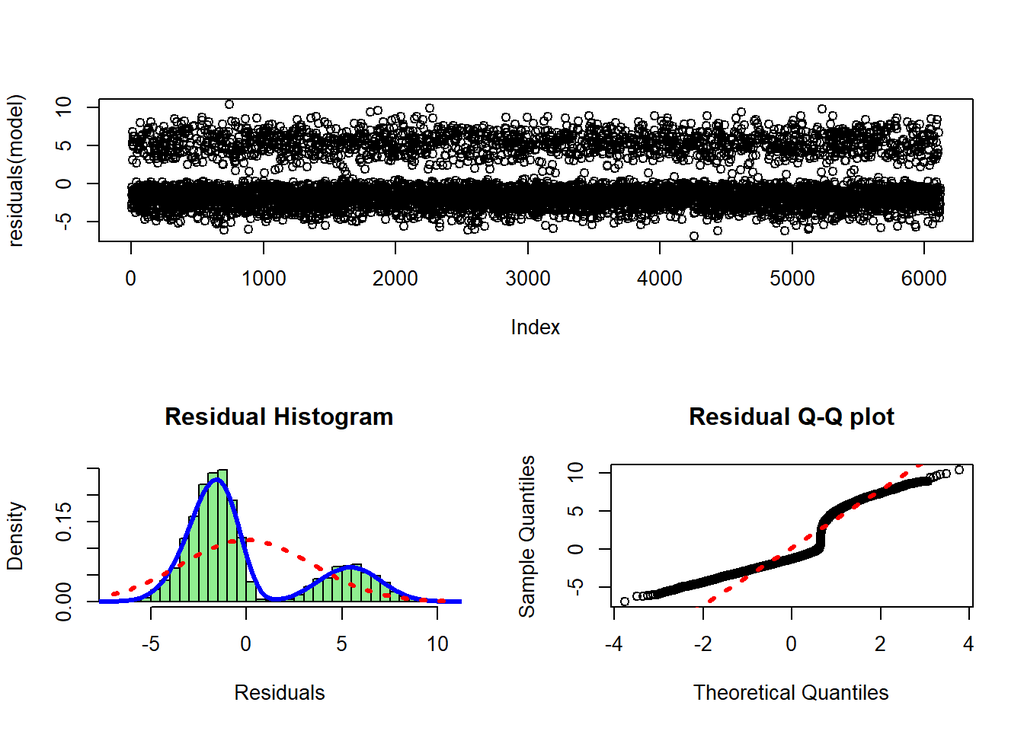

This model did not perform as well linear model 2. This is likely due to the omission of features that were not numeric. The R2 for this model was .12 with a rmse of 3.43

### Logistic Regression Model

#### Logistic Regression Model 1

The next set of models built are logistic regression models. These predict the outcome of non-numeric variables. This is done by assessing the probability that a particular class will occur. In this case, we are doing a binary classification of the feature “TARGET_FLAG” where the outcome is 0 or 1.

Similar to the linear regression models, the first model built was based on the entire dataset. The logistic models will be attempting to predict the feature “TARGET_FLAG” using the existing features within the dataset except for “TARGET_AMT”. These features are to be considered unknown.

```
##
## Call:
## stats::glm(formula = TARGET_FLAG ~ BLUEBOOK + CAR_AGE + HOME_VAL +
##     INCOME + PARENT1 + HOME_VAL + MSTATUS + SEX + EDUCATION +
##     JOB + TRAVTIME + CAR_USE + KIDSDRIV + AGE + HOMEKIDS + YOJ +
##     CAR_TYPE + RED_CAR + OLDCLAIM + CLM_FREQ + REVOKED + MVR_PTS +
##     CAR_AGE + URBANICITY, family = stats::binomial, data = data)
##
## Deviance Residuals:
##     Min       1Q   Median       3Q      Max
## -2.4579  -0.7228  -0.4096   0.6134   2.9266
##
## Coefficients:
##                                   Estimate Std. Error z value Pr(>|z|)
## (Intercept)                     -1.365e+00  3.650e-01  -3.739 0.000184 ***
## BLUEBOOK                        -2.021e-05  6.103e-06  -3.311 0.000930 ***
## CAR_AGE                         -1.335e-02  8.635e-03  -1.546 0.122161
## HOME_VAL                        -1.462e-06  4.007e-07  -3.648 0.000265 ***
## INCOME                          -2.416e-06  1.282e-06  -1.885 0.059487 .
## PARENT1Yes                       3.827e-01  1.258e-01   3.042 0.002348 **
## MSTATUSz_No                      4.646e-01  9.715e-02   4.783 1.73e-06 ***
## SEXz_F                          -6.515e-02  1.284e-01  -0.508 0.611789
## EDUCATIONBachelors              -2.591e-01  1.318e-01  -1.967 0.049233 *
## EDUCATIONMasters                -1.289e-01  2.043e-01  -0.631 0.528268
## EDUCATIONPhD                     6.120e-02  2.420e-01   0.253 0.800332
## EDUCATIONz_High School           6.478e-02  1.092e-01   0.593 0.552861
## JOBClerical                      4.823e-01  2.264e-01   2.130 0.033133 *
## JOBDoctor                       -3.475e-01  3.005e-01  -1.157 0.247454
## JOBHome Maker                    2.940e-01  2.412e-01   1.219 0.222907
## JOBLawyer                        1.357e-01  1.983e-01   0.684 0.493786
## JOBManager                      -4.817e-01  1.989e-01  -2.422 0.015436 *
## JOBProfessional                  2.325e-01  2.062e-01   1.128 0.259475
## JOBStudent                       2.845e-01  2.477e-01   1.149 0.250735
## JOBz_Blue Collar                 4.082e-01  2.131e-01   1.916 0.055399 .
## TRAVTIME                         1.346e-02  2.154e-03   6.247 4.17e-10 ***
## CAR_USEPrivate                  -7.212e-01  1.049e-01  -6.878 6.08e-12 ***
## KIDSDRIV                         3.824e-01  7.017e-02   5.450 5.04e-08 ***
## AGE                              2.761e-03  4.594e-03   0.601 0.547887
## HOMEKIDS                         7.568e-02  4.260e-02   1.777 0.075613 .
## YOJ                             -2.135e-02  9.811e-03  -2.176 0.029533 *
## CAR_TYPEPanel Truck              4.137e-01  1.868e-01   2.214 0.026801 *
## CAR_TYPEPickup                   4.970e-01  1.150e-01   4.321 1.55e-05 ***
## CAR_TYPESports Car               9.410e-01  1.483e-01   6.344 2.24e-10 ***
## CAR_TYPEVan                      6.382e-01  1.440e-01   4.433 9.29e-06 ***
## CAR_TYPEz_SUV                    6.840e-01  1.276e-01   5.360 8.30e-08 ***
## RED_CARyes                      -2.742e-02  1.003e-01  -0.273 0.784523
## OLDCLAIM                        -1.256e-05  4.468e-06  -2.812 0.004927 **
## CLM_FREQ                         1.808e-01  3.295e-02   5.489 4.04e-08 ***
## REVOKEDYes                       8.748e-01  1.040e-01   8.409  < 2e-16 ***
## MVR_PTS                          1.241e-01  1.573e-02   7.889 3.04e-15 ***
## URBANICITYz_Highly Rural/ Rural -2.292e+00  1.280e-01 -17.912  < 2e-16 ***
## ---
## Signif. codes:  0 '***' 0.001 '**' 0.01 '*' 0.05 '.' 0.1 ' ' 1
##
## (Dispersion parameter for binomial family taken to be 1)
##
##     Null deviance: 7037.3  on 6120  degrees of freedom
## Residual deviance: 5529.6  on 6084  degrees of freedom
## AIC: 5603.6
##
## Number of Fisher Scoring iterations: 5
```

#### Logistic Regression Model 2

In the the second logistic regression model, we remove variables will low variance, as well as variables that may exhibit colinearity. Additionally, 4 numeric features from our training set were binned into groups and used as predictors in lieu of numeric based predictors. The plot below shows the 4 features that were chosen to be binned within the analysis.

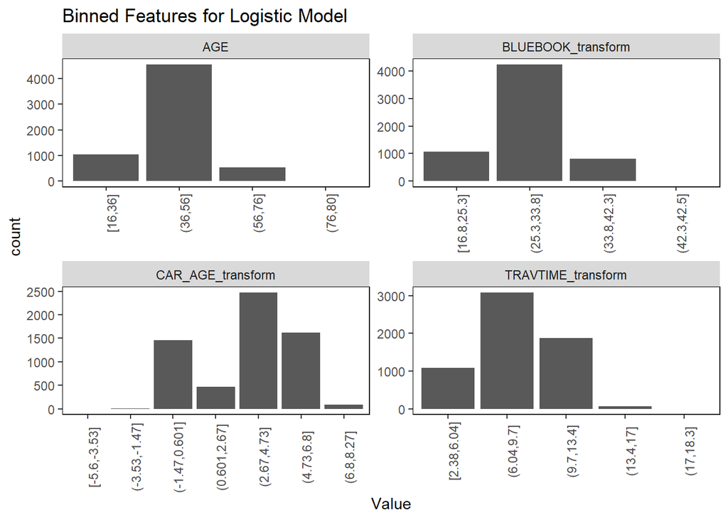

```
##
## Call:
## stats::glm(formula = TARGET_FLAG ~ ., family = stats::binomial,
##     data = data)
##
## Deviance Residuals:
##     Min       1Q   Median       3Q      Max
## -2.3281  -0.6980  -0.3924   0.5596   2.8649
##
## Coefficients:
##                                   Estimate Std. Error z value Pr(>|z|)
## (Intercept)                      1.366e+01  5.354e+02   0.026 0.979645
## AGE(36,56]                      -2.731e-01  9.812e-02  -2.783 0.005379 **
## AGE(56,76]                       6.111e-01  1.473e-01   4.147 3.36e-05 ***
## AGE(76,80]                      -1.030e+01  5.354e+02  -0.019 0.984652
## BLUEBOOK_transform(25.3,33.8]   -3.900e-01  9.400e-02  -4.149 3.35e-05 ***
## BLUEBOOK_transform(33.8,42.3]   -7.578e-01  1.612e-01  -4.701 2.60e-06 ***
## BLUEBOOK_transform(42.3,42.5]   -1.236e+01  5.354e+02  -0.023 0.981587
## CAR_AGE_transform(-3.53,-1.47]  -2.494e+01  6.127e+02  -0.041 0.967532
## CAR_AGE_transform(-1.47,0.601]  -1.373e+01  5.354e+02  -0.026 0.979539
## CAR_AGE_transform(0.601,2.67]   -1.382e+01  5.354e+02  -0.026 0.979400
## CAR_AGE_transform(2.67,4.73]    -1.382e+01  5.354e+02  -0.026 0.979406
## CAR_AGE_transform(4.73,6.8]     -1.396e+01  5.354e+02  -0.026 0.979206
## CAR_AGE_transform(6.8,8.27]     -1.458e+01  5.354e+02  -0.027 0.978268
## CAR_TYPEPanel Truck              4.107e-01  1.842e-01   2.229 0.025817 *
## CAR_TYPEPickup                   5.367e-01  1.168e-01   4.596 4.32e-06 ***
## CAR_TYPESports Car               8.421e-01  1.450e-01   5.809 6.29e-09 ***
## CAR_TYPEVan                      6.090e-01  1.420e-01   4.287 1.81e-05 ***
## CAR_TYPEz_SUV                    6.551e-01  1.224e-01   5.351 8.76e-08 ***
## CAR_USEPrivate                  -7.280e-01  1.065e-01  -6.834 8.27e-12 ***
## CLM_FREQ                         8.306e-02  5.120e-02   1.622 0.104750
## EDUCATIONBachelors              -2.377e-01  1.343e-01  -1.770 0.076775 .
## EDUCATIONMasters                -1.111e-01  2.062e-01  -0.539 0.589842
## EDUCATIONPhD                    -1.231e-02  2.383e-01  -0.052 0.958792
## EDUCATIONz_High School           7.617e-02  1.123e-01   0.678 0.497690
## HOME_VAL_transform              -3.941e-04  9.860e-05  -3.997 6.41e-05 ***
## HOMEKIDS                         4.233e-02  4.299e-02   0.985 0.324831
## INCOME_transform                -1.242e-02  3.261e-03  -3.810 0.000139 ***
## JOBClerical                      4.536e-01  2.283e-01   1.987 0.046921 *
## JOBDoctor                       -4.580e-01  3.031e-01  -1.511 0.130741
```

[output cut: 16 more lines]

```
## TRAVTIME_transform(9.7,13.4]     6.150e-01  1.039e-01   5.917 3.28e-09 ***
## TRAVTIME_transform(13.4,17]      1.988e-01  3.811e-01   0.522 0.601996
## TRAVTIME_transform(17,18.3]     -9.893e+00  3.637e+02  -0.027 0.978298
## URBANICITYz_Highly Rural/ Rural -2.284e+00  1.289e-01 -17.721  < 2e-16 ***
## YOJ                             -4.063e-03  1.162e-02  -0.350 0.726558
## ---
## Signif. codes:  0 '***' 0.001 '**' 0.01 '*' 0.05 '.' 0.1 ' ' 1
##
## (Dispersion parameter for binomial family taken to be 1)
##
##     Null deviance: 7037.3  on 6120  degrees of freedom
## Residual deviance: 5386.6  on 6071  degrees of freedom
## AIC: 5486.6
##
## Number of Fisher Scoring iterations: 12
```

With this, the logistic model was run and the results show and AIC 5486. This is lower than the first model and implies that this is better at predicting the classification for TARGET_FLAG.

#### Logistic Regression Model 3

```
##
##         0         1
## 0.7361843 0.2638157
```

Because of this class imbalance, if we were to simply guess that all values are 0, that would technically lead to a 73% accurate model. To account for this, we will downsample the majority class in the final logistic model. This downsampling will allow the distribution of the training set to be 50/50. The testing dataset will remain as is.

```
##
##   0   1
## 0.5 0.5
```

```
##
## Call:
## stats::glm(formula = TARGET_FLAG ~ ., family = stats::binomial,
##     data = data)
##
## Deviance Residuals:
##      Min        1Q    Median        3Q       Max
## -2.82953  -0.83526   0.00015   0.82576   2.50218
##
## Coefficients:
##                                   Estimate Std. Error z value Pr(>|z|)
## (Intercept)                      1.378e+01  5.354e+02   0.026 0.979460
## AGE(36,56]                      -2.449e-01  1.276e-01  -1.919 0.054974 .
## AGE(56,76]                       7.372e-01  1.942e-01   3.796 0.000147 ***
## BLUEBOOK_transform(25.3,33.8]   -3.761e-01  1.208e-01  -3.115 0.001841 **
## BLUEBOOK_transform(33.8,42.3]   -6.091e-01  2.048e-01  -2.974 0.002938 **
## CAR_AGE_transform(-3.53,-1.47]  -2.436e+01  6.527e+02  -0.037 0.970231
## CAR_AGE_transform(-1.47,0.601]  -1.285e+01  5.354e+02  -0.024 0.980847
## CAR_AGE_transform(0.601,2.67]   -1.300e+01  5.354e+02  -0.024 0.980634
## CAR_AGE_transform(2.67,4.73]    -1.289e+01  5.354e+02  -0.024 0.980786
## CAR_AGE_transform(4.73,6.8]     -1.294e+01  5.354e+02  -0.024 0.980713
## CAR_AGE_transform(6.8,8.27]     -1.358e+01  5.354e+02  -0.025 0.979771
## CAR_TYPEPanel Truck              2.423e-01  2.348e-01   1.032 0.302085
## CAR_TYPEPickup                   4.567e-01  1.466e-01   3.114 0.001843 **
## CAR_TYPESports Car               9.331e-01  1.826e-01   5.111 3.21e-07 ***
## CAR_TYPEVan                      6.007e-01  1.763e-01   3.407 0.000656 ***
## CAR_TYPEz_SUV                    8.021e-01  1.522e-01   5.271 1.36e-07 ***
## CAR_USEPrivate                  -8.733e-01  1.372e-01  -6.363 1.97e-10 ***
## CLM_FREQ                         4.885e-02  6.803e-02   0.718 0.472684
## EDUCATIONBachelors              -1.693e-01  1.698e-01  -0.997 0.318597
## EDUCATIONMasters                 1.281e-01  2.597e-01   0.493 0.621944
## EDUCATIONPhD                     1.612e-01  3.065e-01   0.526 0.598818
## EDUCATIONz_High School           2.225e-01  1.431e-01   1.554 0.120126
## HOME_VAL_transform              -4.454e-04  1.260e-04  -3.536 0.000406 ***
## HOMEKIDS                         4.943e-02  5.482e-02   0.902 0.367285
## INCOME_transform                -1.497e-02  4.155e-03  -3.602 0.000316 ***
## JOBClerical                      6.519e-01  2.832e-01   2.302 0.021346 *
## JOBDoctor                       -5.432e-01  3.608e-01  -1.505 0.132216
## JOBHome Maker                    1.465e-01  3.209e-01   0.457 0.647987
## JOBLawyer                       -1.019e-02  2.452e-01  -0.042 0.966858
```

[output cut: 13 more lines]

```
## TRAVTIME_transform(6.04,9.7]     2.548e-01  1.221e-01   2.086 0.036937 *
## TRAVTIME_transform(9.7,13.4]     5.980e-01  1.318e-01   4.537 5.71e-06 ***
## TRAVTIME_transform(13.4,17]      3.339e-01  4.397e-01   0.759 0.447682
## URBANICITYz_Highly Rural/ Rural -2.310e+00  1.496e-01 -15.442  < 2e-16 ***
## YOJ                             -6.071e-03  1.495e-02  -0.406 0.684613
## ---
## Signif. codes:  0 '***' 0.001 '**' 0.01 '*' 0.05 '.' 0.1 ' ' 1
##
## (Dispersion parameter for binomial family taken to be 1)
##
##     Null deviance: 4441.7  on 3203  degrees of freedom
## Residual deviance: 3256.3  on 3157  degrees of freedom
## AIC: 3350.3
##
## Number of Fisher Scoring iterations: 12
```

With this we end up with a model that has an AIC score of 3350, significantly less than that of the first two logistic models and thus we can say that this model has performed better. Additional metrics on each model are presented in the Model Performance Summary at the end of this document.

#### Using Logistic Results to improve Linear Regression

Finally, to tune the linear regression model, we added the predictions made from our final logistic regression model to obtain the feature TARGET_FLAG. With this, an additional predictor feature was added to the model and could be used.

```
##
## Call:
## stats::lm(formula = TARGET_AMT_transform ~ ., data = data)
##
## Residuals:
##    Min     1Q Median     3Q    Max
## -7.727 -1.984 -0.934  1.376 10.497
##
## Coefficients:
##                                   Estimate Std. Error t value Pr(>|t|)
## (Intercept)                      1.246e+00  6.105e-01   2.040 0.041354 *
## AGE                             -2.257e-03  5.743e-03  -0.393 0.694378
## BLUEBOOK_transform              -3.672e-02  1.339e-02  -2.742 0.006116 **
## CAR_AGE_transform               -3.407e-02  2.569e-02  -1.326 0.184855
## CAR_TYPEPanel Truck              2.849e-01  2.147e-01   1.326 0.184727
## CAR_TYPEPickup                   4.113e-01  1.382e-01   2.976 0.002932 **
## CAR_TYPESports Car               7.874e-01  1.772e-01   4.442 9.06e-06 ***
## CAR_TYPEVan                      5.357e-01  1.714e-01   3.126 0.001780 **
## CAR_TYPEz_SUV                    5.735e-01  1.443e-01   3.974 7.15e-05 ***
## CAR_USEPrivate                  -6.676e-01  1.342e-01  -4.973 6.76e-07 ***
## CLM_FREQ                         7.363e-02  6.978e-02   1.055 0.291406
## EDUCATIONBachelors              -2.035e-01  1.667e-01  -1.221 0.222189
## EDUCATIONMasters                -6.280e-02  2.383e-01  -0.264 0.792147
## EDUCATIONPhD                     2.707e-02  2.765e-01   0.098 0.922005
## EDUCATIONz_High School           9.169e-02  1.398e-01   0.656 0.511972
## HOME_VAL_transform              -3.179e-04  1.224e-04  -2.597 0.009425 **
## HOMEKIDS                         5.050e-02  5.338e-02   0.946 0.344149
## INCOME_transform                -9.809e-03  3.982e-03  -2.463 0.013799 *
## JOBClerical                      4.233e-01  2.750e-01   1.539 0.123779
## JOBDoctor                       -3.403e-01  3.293e-01  -1.033 0.301539
## JOBHome Maker                    1.046e-01  3.110e-01   0.336 0.736672
## JOBLawyer                        1.100e-01  2.392e-01   0.460 0.645415
## JOBManager                      -4.648e-01  2.329e-01  -1.996 0.045990 *
## JOBProfessional                  2.828e-01  2.492e-01   1.135 0.256480
## JOBStudent                       1.505e-03  3.230e-01   0.005 0.996283
## JOBz_Blue Collar                 4.361e-01  2.603e-01   1.675 0.093914 .
## KIDSDRIV                         3.460e-01  9.285e-02   3.727 0.000196 ***
## MSTATUSz_No                      4.229e-01  1.226e-01   3.450 0.000564 ***
## MVR_PTS                          1.088e-01  2.233e-02   4.872 1.13e-06 ***
## OLDCLAIM_transform               2.079e-02  1.959e-02   1.062 0.288441
## PARENT1Yes                       3.327e-01  1.648e-01   2.019 0.043492 *
## RED_CARyes                      -1.425e-02  1.217e-01  -0.117 0.906781
## REVOKEDYes                       6.398e-01  1.301e-01   4.917 9.00e-07 ***
## SEXz_F                          -4.570e-02  1.466e-01  -0.312 0.755234
## TIF_transform                   -2.154e-01  3.897e-02  -5.528 3.38e-08 ***
## TRAVTIME_transform               7.394e-02  1.643e-02   4.499 6.96e-06 ***
## URBANICITYz_Highly Rural/ Rural -1.861e+00  1.204e-01 -15.463  < 2e-16 ***
## YOJ                              2.166e-05  1.408e-02   0.002 0.998773
## preds                            1.954e+00  1.505e-01  12.980  < 2e-16 ***
## ---
## Signif. codes:  0 '***' 0.001 '**' 0.01 '*' 0.05 '.' 0.1 ' ' 1
##
## Residual standard error: 3.186 on 6082 degrees of freedom
## Multiple R-squared:  0.2476, Adjusted R-squared:  0.2429
## F-statistic: 52.67 on 38 and 6082 DF,  p-value: < 2.2e-16
```

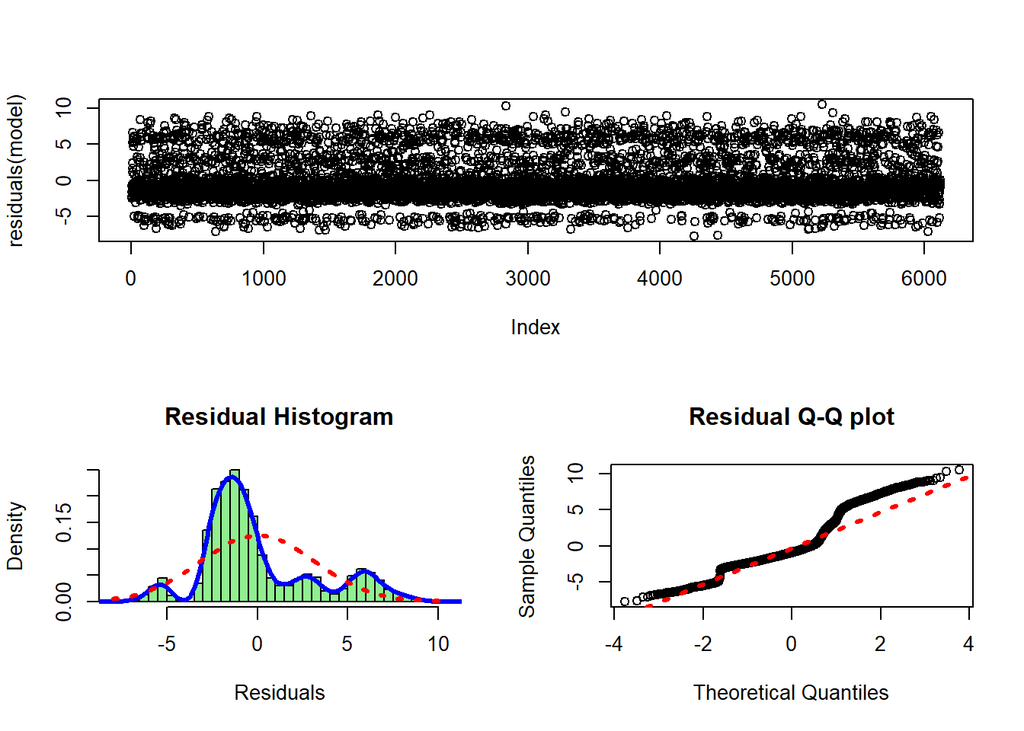

After using the results of the optimal logistic regression model to predict TARGET_FLAG and passing that into a linear regression, the R2 for the model has bumped up to 0.2476 with a standard error of 3.186.

### Model Performance Summary

Finally, we can view the results of each of the linear regression models. The results for both the training and testing datasets are plotted below. There are many datapoints where `TARGET_FLAG` is 0 and thus leads to regression plots that may be weighted accordingly. Omitting points with 0 does not improve the model.

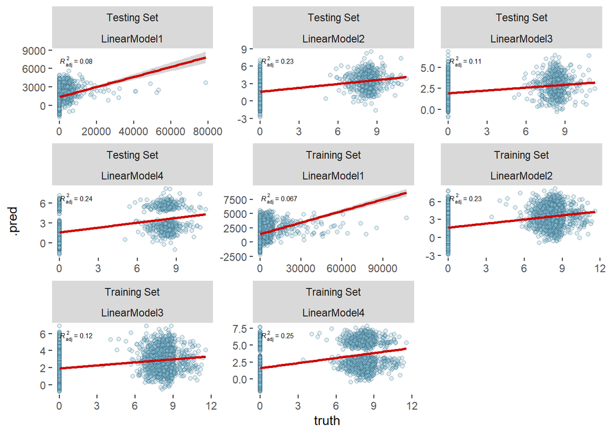

The results for both the training and testing datasets on each of the models is presented below. The linear model that performed the best on this dataset to predict our response variable `TARGET_AMT` is linear model 4. This model uses all predictor variables with transformations done to normalize numeric variables that did not follow gaussian distributions. Additionally, the predictor variable `TARGET_FLAG` was included in this analysis via prediction from the logistic regression model. Although this model may be the best of the four, it may not be sufficient in real life use cases as the $R^2$ implies that the model explains about 24% of the variance within the dataset. The results were consistent between the testing and the training datasets implying that no minimal overfitting/underfitting occured.

| model | set | rmse | rsq | mae |
| --- | --- | --- | --- | --- |
| LinearModel1 | Training Set | 4660.736206 | 0.0673940 | 1994.766874 |
| LinearModel2 | Training Set | 3.219356 | 0.2267470 | 2.606465 |
| LinearModel3 | Training Set | 3.432846 | 0.1207904 | 2.813728 |
| LinearModel4 | Training Set | 3.175672 | 0.2475892 | 2.460059 |

| model | set | rmse | rsq | mae |
| --- | --- | --- | --- | --- |
| LinearModel1 | Testing Set | 4138.492195 | 0.0803887 | 1919.310196 |
| LinearModel2 | Testing Set | 3.243748 | 0.2326278 | 2.621742 |
| LinearModel3 | Testing Set | 3.484797 | 0.1132622 | 2.874374 |
| LinearModel4 | Testing Set | 3.218473 | 0.2448160 | 2.488462 |

| model | set | accuracy | kap |
| --- | --- | --- | --- |
| LogisticModel1 | Training Set | 0.7907205 | 0.3775704 |
| LogisticModel2 | Training Set | 0.7998693 | 0.4142744 |
| LogisticModel3 | Training Set | 0.7506242 | 0.5012484 |

| model | set | accuracy | kap |
| --- | --- | --- | --- |
| LogisticModel1 | Testing Set | 0.7887255 | 0.3842650 |
| LogisticModel2 | Testing Set | 0.7855741 | 0.3788016 |
| LogisticModel3 | Testing Set | 0.7262022 | 0.4075439 |

The final thing we will take a look at is our variable importance for each model.

The final figure presented below shows the feature importance in each model. Note that not all features are presented from the models, but only the top 6 from each. Amongst all the models with the exception of linear model 3 (which did not consider ordinal features), being in an urban city that was highly rural was best predictor of when someone was in a car crash and if they would file claims against their insurance accordingly. Motor vehicle points was also a consistent feature that shows that people who have a history of violations tend to be more likely to get into a car accident. This is consistent with how car insurance plans are priced with high premiums being charged in urban areas like NYC relative to the suburbs.

[figure not shown]

## References

- A Modern Approach to Regression with R: Simon Sheather
- Linear Models with R: Julian Faraway.
- R package vignette, [mixtools: An R Package for Analyzing Finite Mixture Models](https://cran.r-project.org/web/packages/mixtools/vignettes/mixtools.pdf)

### R Code

```
# =====================================================================================
# Load Libraries and Define Helper functions
# =====================================================================================

include=FALSE, paged.print=FALSE}
library(MASS)
library(scales)
library(rpart.plot)
library(ggplot2)
library(ggfortify)
library(gridExtra)
library(forecast)
library(fpp2)
library(fma)
library(kableExtra)
library(e1071)
library(mlbench)
library(ggcorrplot)
library(DataExplorer)
library(timeDate)
library(caret)
library(GGally)
library(corrplot)
library(RColorBrewer)
library(tibble)
library(tidyr)
library(tidyverse)
library(tidyselect)
library(dplyr)
library(reshape2)
library(mixtools)
library(tidymodels)
library(ggpmisc)
library(regclass)
library(pROC)
library(naniar)
library(RANN)
#' Print a side-by-side Histogram and QQPlot of Residuals
#'
#' @param model A model
```

[output cut: 583 more lines]

```
  group_by(model,set) %>%
metrics(truth = truth, estimate = .pred_class) %>%
  select(-c('.estimator')) %>%
  pivot_wider(names_from = '.metric',values_from = '.estimate')%>%
  #pushing to kable style table
  kable() %>%
  kable_styling(
    bootstrap_options = c("hover", "condensed", "responsive"),
    full_width = F)

grid.arrange(linVP1,linVP2,linVP3,logVP1,logVP2,logVP3,linVP4,ncol = 3)

# =====================================================================================
End of R Code
# =====================================================================================
```